# Decision Trees

Day 16

## Decision Trees

- Basic idea: Build a model that splits the sample into regions that best explain our variable of interest
- Example: If you are looking to hire a fresh college grad, what three questions would you ask?
  - In this example our variable of interest is “Good worker”, “Bad worker”
  - Good questions will allow you to better decide whether that candidate is “Good worker”, or “Bad worker”
  - Bad questions will not be at all correlated with “Good worker” or “Bad worker”
- Loans: suppose we just want to use Duration and Credit amount to predict default. What combinations lead to default?

## Loans example

- Split the predictor space into regions for each outcome

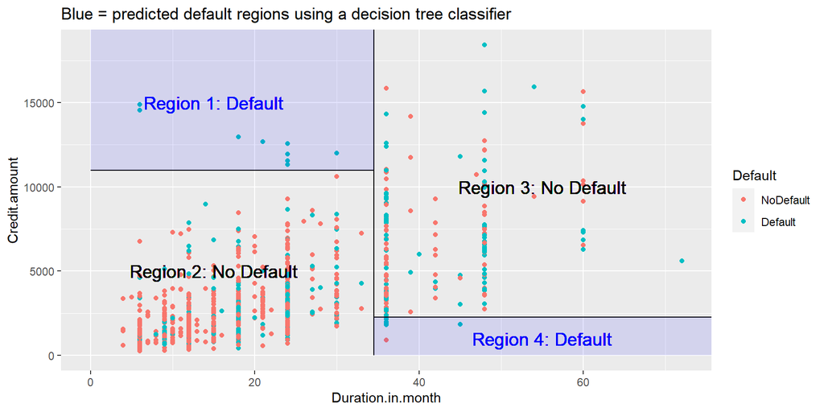

## Comparison with Logistic regression

- Generalized linear models can only split the region into two based on some curve

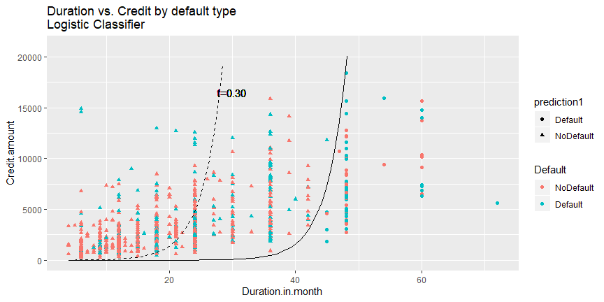

## Loans example

- A decision tree divided the predictor space into four regions, two of which were majority default responses and hence are predicted default regions
- The accuracy of this model is 71.5%

```r
> conf_mat
           pred_dtree
Default     NoDefault Default
  NoDefault       699       1
  Default         284      16
> sum(diag(conf_mat))/sum(conf_mat)
[1] 0.715
```

- logistic regression: 70.9%

## Loans example

- A tree view of this model:
- Think of it like 20 questions (each node corresponds with a region)

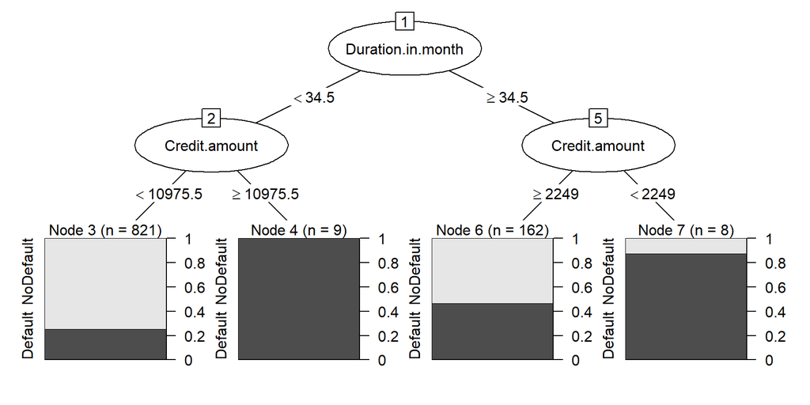

## Decision trees

- Consider the top node of the loans data: 1000 cases (30% default)
  - which cuts of Duration or Credit will make subsets that are more “pure” (homogeneous)? how many splits based on Duration do we have to consider? by Credit?
- The top-level node was split into two child nodes:
  - duration < 34.5: 26.3% default (218/(218+612))
  - duration >= 34.5: 48.2% default (82/(82+88))

## Decision trees

- How do we determine the *best* split (if any) at each node?
- A node is split (or not) based on a “purity” measure
  - Gini coefficient: \(Gini(t)=\sum_{i=1}^2w_i(t)(1-w_i(t))\)
- \(t\) represents the node, and \(w_i(t)\) represents the fraction of records belonging to class \(i\)
  - Ex: If `duration > 50` split `default` and `no default` evenly
    - \(0.5 \times 0.5 + 0.5 \times 0.5=0.5\). This is the “worst” case
  - Ex: If `duration > 50` split `default` and `no default` perfectly
    - \(1 \times 0 + 0 \times 1=0\). This is the “best” case
- measures closer to 0 indicate higher purity (wrt y) among the cases in a node
- `rpart` uses the Gini coefficient as default

## Decision trees

- a node is split into two child nodes if the purity of the children exceeds the purity of the parent node by a threshold (aka stopping criteria)
  - `rpart` default will split a node if the purity of a child is 1% better than parent
  - can change stopping criteria to obtain different trees

## Decision trees

- How do we make predictions?
  - convention is to use the “majority” class within each node
    - \(\hat{y} = Success\): more than 50% of cases in a node are success
    - \(\hat{y} = Failure\): less than 50% of cases in a node are success

## Using `rpart` package

- This first decision tree used the `rpart` (recursive partitioning) package and function
- To make a “simple” tree, I set the `maxdepth` value to 2:
  - this stops splitting after 2 splits

```r
> loans_rpart <- rpart(Default ~ Credit.amount + Duration.in.month,
+                      data=loans, control=rpart.control(maxdepth=2))
```

## Using `rpart` package

- The `rpart` object shows the tree structure in list form, with **terminal** nodes highlighted with *

```r
> loans_rpart
n= 1000

node), split, n, loss, yval, (yprob)
      * denotes terminal node

1) root 1000 300 NoDefault (0.7000000 0.3000000)
  2) Duration.in.month< 34.5 830 218 NoDefault (0.7373494 0.2626506)
    4) Credit.amount< 10975.5 821 209 NoDefault (0.7454324 0.2545676) *
    5) Credit.amount>=10975.5 9   0 Default (0.0000000 1.0000000) *
  3) Duration.in.month>=34.5 170  82 NoDefault (0.5176471 0.4823529)
    6) Credit.amount>=2249 162  75 NoDefault (0.5370370 0.4629630) *
    7) Credit.amount< 2249 8   1 Default (0.1250000 0.8750000) *
```

## Graphing the tree

- Use the `partykit` package:

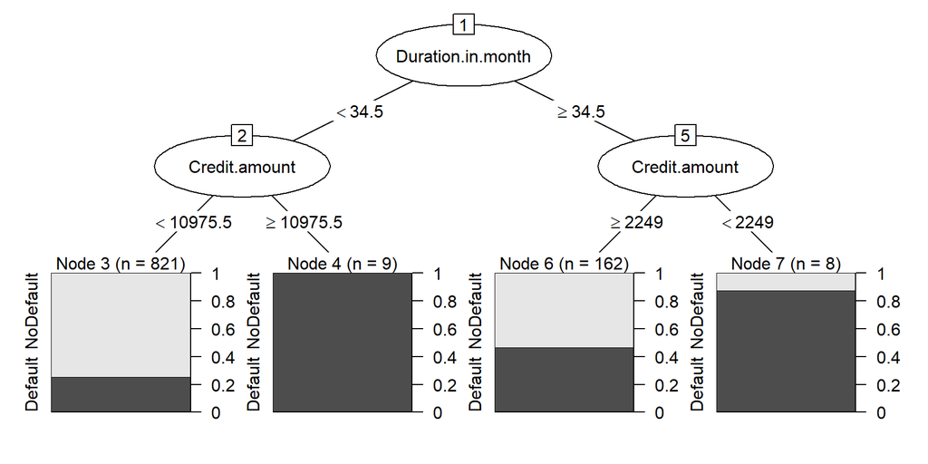

```r
> plot(as.party(loans_rpart))
```

## Graphing the tree

- simple version has no bar plot

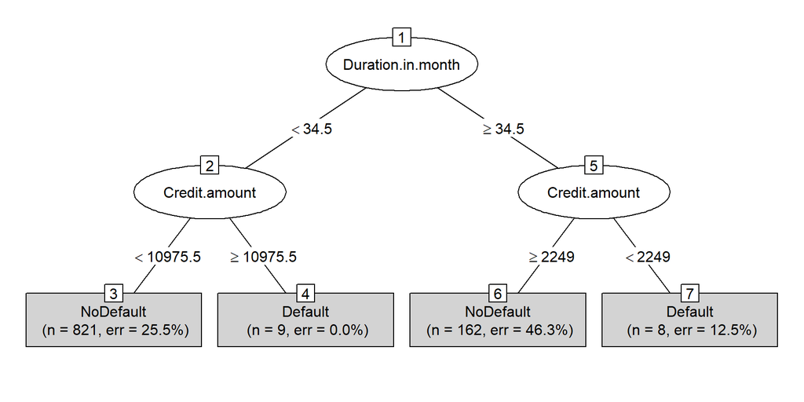

```r
> plot(as.party(loans_rpart), type="simple")
```

## Prediction

- Use `type="class"` to get predictions

```r
> loans %>% mutate(predictions = predict(loans_rpart, type="class")) %>%
+   select(Default, predictions, Duration.in.month, Credit.amount) %>% print(n=6)
# A tibble: 1,000 x 4
  Default   predictions Duration.in.month Credit.amount
  <fct>     <fct>                   <dbl>         <dbl>
1 NoDefault NoDefault                   6          1169
2 Default   NoDefault                  48          5951
3 NoDefault NoDefault                  12          2096
4 NoDefault NoDefault                  42          7882
5 Default   NoDefault                  24          4870
6 NoDefault NoDefault                  36          9055
# ... with 994 more rows
```

## Loans example: More flexible model

- Earlier I restricted the tree depth to 2
- Now, relax that restriction

```r
> loans_rpart <- rpart(Default ~ Credit.amount + Duration.in.month,
+                      data=loans)
> loans %>% mutate(prediction = predict(loans_rpart, type="class")) %>%
+   summarize(accuracy = mean(Default == prediction))
# A tibble: 1 x 1
  accuracy
     <dbl>
1    0.733
```

- Accuracy is slightly higher (73.3% vs 71.5%)

## Loans example: More flexible model

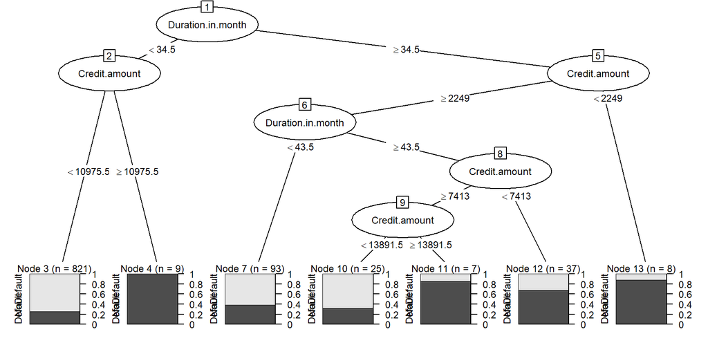

## Loans example: change parameter

- Change `cp`: need a 1.5% improvement in Gini index for a split
- Should we get more or fewer splits?

```r
> loans_rpart <- rpart(Default ~ Credit.amount + Duration.in.month, data=loans,
+                      control=rpart.control(cp=.015))
> loans %>% mutate(prediction = predict(loans_rpart, type="class")) %>%
+   summarize(accuracy = mean(Default == prediction))
# A tibble: 1 x 1
  accuracy
     <dbl>
1    0.724
```

- Accuracy is slightly lower (72.4%) and fewer splits

## Loans example: change parameter

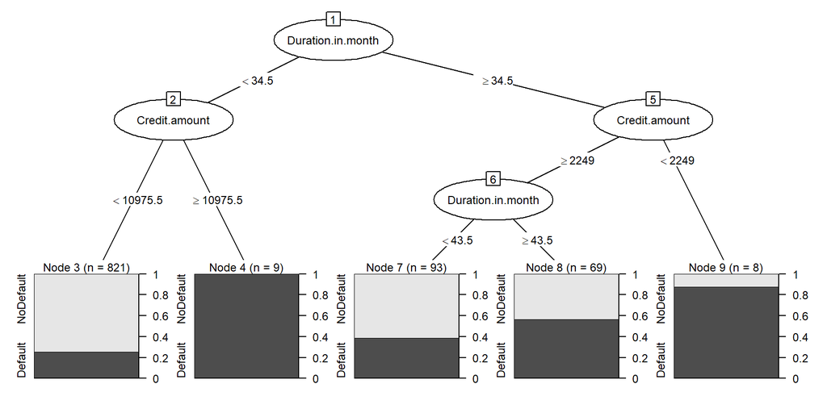

## When to use decision trees?

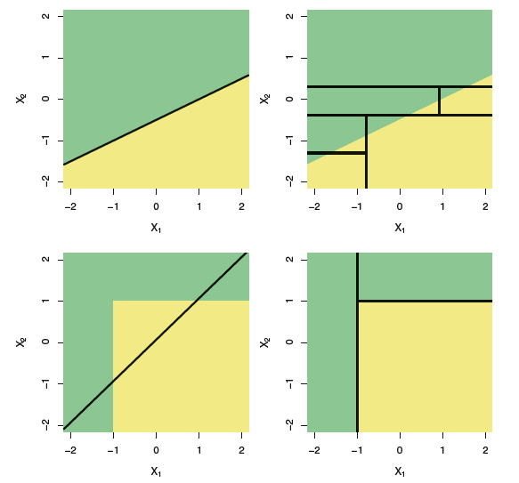

- If boundaries are linear (first row), then linear methods outperform
- If boundaries are non-linear (second row), tree methods will do well
- Ex: Predict meat consumption by income (across the whole world)
  - In some parts of Asia, higher income associated with eating more meat
  - In the U.S. higher income associated with eating less meat
  - Easy to capture this with decision tree, but harder with linear methods

## Final comments:

- Decision trees are generally easy to make and understand
- They have more “tuning parameters” than other models
  - What is the gini coefficient cutoff?
  - What is the maximum depth of the tree?
  - What is the minimum observations in each leaf
- Biggest criticism is overfitting: they might look great on a training set but perform poorly on a test set
- Solution: use cross-validation or other methods (next class)